# Projet Statistique bayésienne

MAHAMAT HASSAN ISSA

2023-08-12

# préparation des données

```r
#preparation des données:

{

  d=read.csv("C:/Users/HP/Desktop/Module 2/Bayèsien/Projet/mutations2.csv",stringsAsFactors = F)

  d_noduplicate = d %>% distinct()

  y = d_noduplicate$Barre
  #mat X pour les coef: sans les variables catégorielles
  X = as.matrix(d_noduplicate[,-c(1:6)])

  summary(lm(y~X))
  betahat = (lm(y~X))$coefficients
  residuals = lm(y~X)$residuals
  s2 = t(residuals)%*%residuals


  #on utilise laprior de Zelner: loi non informative de paramétre g
  #pour simplifier les calculs on ajouter une colenne de 1 (pour l'intercepte)
  X = cbind(1,X)
  n = NROW(X)

}


#glimpse(d)

#levels(d$etablissement)


#summary(d)
```

Le fichier mutation2.csv contient 23 variables et 516 individus. Les 5 premières variables sont qualitatives et renseignent l’établissement, les matières concernées et d’autres paramètres identifiants les établissements (ville, code, etc.). À noter que la variable établissement ne renseigne pas les établissements de façon unique, car plusieurs noms sont similaires pour des lycées de différentes communes. Dans la suite de l’étude, la variable code_etablissement sera utilisée comme référence.

Les 18 variables suivantes sont numériques en renseignent les caractéristiques de chaque couple (établissement, matière), notamment les effectifs, taux de réussite et d’accès aux fillaires et la variable réponse Barre qui indique le nombre de points nécessaire pour une mutation dans un couple donné.

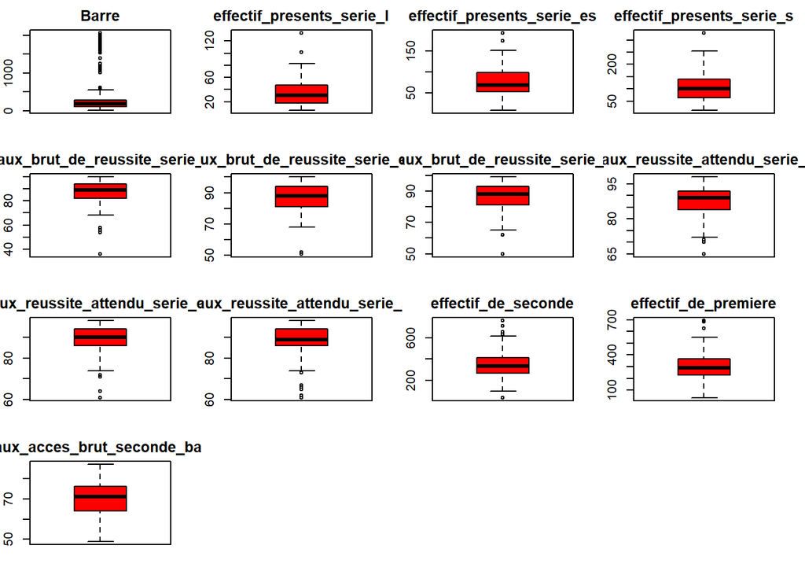

```r
#visualisation des données
#boxplot
par(mfrow = c(4,4))
par(mar = rep(2,4))
for (i in c(6:18)) {
  boxplot(d[,i], main=colnames(d[i]), col=c("red","blue"))

}

#histogramme

par(mfrow = c(4,4))
```

```r
par(mar = rep(2,4))
for (i in c(6:18)) {
  hist(d[,i], main=colnames(d[i]), col=c("blue"))

}

#visualisation des matières X établissements
d %>%  distinct(code_etablissement) %>% summarise(nbmat = n())
```

[output not shown]

```
##   nbmat
## 1   107
```

```r
d %>%  distinct(Matiere) %>% summarise(nbmat = n())
```

```
##   nbmat
## 1    35
```

```r
d_Graph = d

NROW(levels(d_Graph$code_etablissement))
```

```
## [1] 0
```

```r
d_Graph$ct = 1
d_Graph$id = 1:NROW(d_Graph)

glimpse(d)
```

```
## Rows: 516
## Columns: 23
## $ code_etablissement                 <chr> "0780422K", "0780422K", "0780422K",…
## $ ville                              <chr> "LES MUREAUX", "LES MUREAUX", "LES …
## $ etablissement                      <chr> "LYCEE FRANCOIS VILLON", "LYCEE FRA…
## $ commune                            <int> 78440, 78440, 78440, 78383, 78383, …
## $ Matiere                            <chr> "PHY.CHIMIE", "MATHS", "DOC LYCEES"…
## $ Barre                              <dbl> 118.0, 93.0, 38.0, 199.0, 48.0, 256…
## $ effectif_presents_serie_l          <int> 25, 25, 25, 34, 34, 34, 21, 21, 21,…
## $ effectif_presents_serie_es         <int> 54, 54, 54, 47, 47, 47, 47, 47, 47,…
## $ effectif_presents_serie_s          <int> 97, 97, 97, 47, 47, 47, 81, 81, 81,…
## $ taux_brut_de_reussite_serie_l      <int> 56, 56, 56, 79, 79, 79, 86, 86, 86,…
## $ taux_brut_de_reussite_serie_es     <int> 85, 85, 85, 98, 98, 98, 96, 96, 96,…
## $ taux_brut_de_reussite_serie_s      <int> 80, 80, 80, 85, 85, 85, 90, 90, 90,…
## $ taux_reussite_attendu_serie_l      <int> 72, 72, 72, 87, 87, 87, 90, 90, 90,…
## $ taux_reussite_attendu_serie_es     <int> 86, 86, 86, 93, 93, 93, 95, 95, 95,…
## $ taux_reussite_attendu_serie_s      <int> 75, 75, 75, 91, 91, 91, 93, 93, 93,…
## $ effectif_de_seconde                <int> 304, 304, 304, 194, 194, 194, 238, …
## $ effectif_de_premiere               <int> 222, 222, 222, 168, 168, 168, 252, …
## $ taux_acces_brut_seconde_bac        <int> 61, 61, 61, 80, 80, 80, 77, 77, 77,…
## $ taux_acces_attendu_seconde_bac     <int> 64, 64, 64, 69, 69, 69, 73, 73, 73,…
## $ taux_acces_brut_premiere_bac       <int> 84, 84, 84, 92, 92, 92, 88, 88, 88,…
## $ taux_acces_attendu_premiere_bac    <int> 81, 81, 81, 87, 87, 87, 87, 87, 87,…
## $ taux_brut_de_reussite_total_series <int> 81, 81, 81, 88, 88, 88, 92, 92, 92,…
## $ taux_reussite_attendu_total_series <int> 79, 79, 79, 89, 89, 89, 92, 92, 92,…
```

```r
glimpse(d_Graph)
```

```
## Rows: 516
## Columns: 25
## $ code_etablissement                 <chr> "0780422K", "0780422K", "0780422K",…
## $ ville                              <chr> "LES MUREAUX", "LES MUREAUX", "LES …
## $ etablissement                      <chr> "LYCEE FRANCOIS VILLON", "LYCEE FRA…
## $ commune                            <int> 78440, 78440, 78440, 78383, 78383, …
## $ Matiere                            <chr> "PHY.CHIMIE", "MATHS", "DOC LYCEES"…
## $ Barre                              <dbl> 118.0, 93.0, 38.0, 199.0, 48.0, 256…
## $ effectif_presents_serie_l          <int> 25, 25, 25, 34, 34, 34, 21, 21, 21,…
## $ effectif_presents_serie_es         <int> 54, 54, 54, 47, 47, 47, 47, 47, 47,…
## $ effectif_presents_serie_s          <int> 97, 97, 97, 47, 47, 47, 81, 81, 81,…
## $ taux_brut_de_reussite_serie_l      <int> 56, 56, 56, 79, 79, 79, 86, 86, 86,…
## $ taux_brut_de_reussite_serie_es     <int> 85, 85, 85, 98, 98, 98, 96, 96, 96,…
## $ taux_brut_de_reussite_serie_s      <int> 80, 80, 80, 85, 85, 85, 90, 90, 90,…
## $ taux_reussite_attendu_serie_l      <int> 72, 72, 72, 87, 87, 87, 90, 90, 90,…
## $ taux_reussite_attendu_serie_es     <int> 86, 86, 86, 93, 93, 93, 95, 95, 95,…
## $ taux_reussite_attendu_serie_s      <int> 75, 75, 75, 91, 91, 91, 93, 93, 93,…
## $ effectif_de_seconde                <int> 304, 304, 304, 194, 194, 194, 238, …
## $ effectif_de_premiere               <int> 222, 222, 222, 168, 168, 168, 252, …
## $ taux_acces_brut_seconde_bac        <int> 61, 61, 61, 80, 80, 80, 77, 77, 77,…
## $ taux_acces_attendu_seconde_bac     <int> 64, 64, 64, 69, 69, 69, 73, 73, 73,…
## $ taux_acces_brut_premiere_bac       <int> 84, 84, 84, 92, 92, 92, 88, 88, 88,…
## $ taux_acces_attendu_premiere_bac    <int> 81, 81, 81, 87, 87, 87, 87, 87, 87,…
## $ taux_brut_de_reussite_total_series <int> 81, 81, 81, 88, 88, 88, 92, 92, 92,…
## $ taux_reussite_attendu_total_series <int> 79, 79, 79, 89, 89, 89, 92, 92, 92,…
## $ ct                                 <dbl> 1, 1, 1, 1, 1, 1, 1, 1, 1, 1, 1, 1,…
## $ id                                 <int> 1, 2, 3, 4, 5, 6, 7, 8, 9, 10, 11, …
```

```r
d_Graph = d_Graph %>% spread(key = Matiere, value = ct)

d_Graph  = d_Graph[-c(2:23)]
d_Graph[is.na(d_Graph)] = 0

d_Graph =d_Graph %>% group_by(code_etablissement) %>% summarise_all(sum)

#summary(d_Graph)

#107 etablissements alors que distinc etab

d_Graph %>%  distinct(code_etablissement) %>% summarise(nbmat = n())
```

```
## # A tibble: 1 × 1
##   nbmat
##   <int>
## 1   107
```

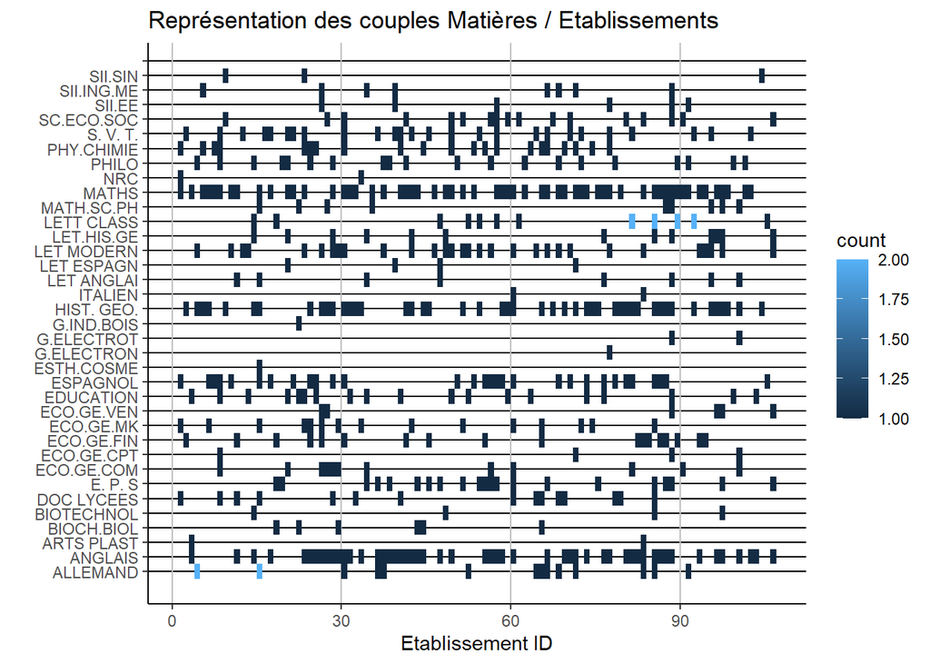

```r
d_Graph$code_etablissement = 1:NROW(d_Graph)

#colnames(d_Graph)[2:NCOL(d_Graph)] = 1:(NCOL(d_Graph)-1)


#generate graph data
{
  df_2dgraph = data.frame(
    x = rep(0,107*36),
    y = rep(0,107*36))

  count = 1
  for (x in  1:107){
    for (y in 2:36) {
      if (d_Graph[x,y] > 0) {
        for (nb in 1:as.numeric((d_Graph[x,y]))) {
          df_2dgraph$x[count]=x
          df_2dgraph$y[count]=y-.5
          count = count +1
        }

      }
    }
  }
}
filter <- dplyr::filter
ggplot((df_2dgraph %>% filter(x!=0)), aes(x=x, y=y) ) +
  geom_bin2d(binwidth = c(1, 1)) +
  theme_classic()+
  scale_y_continuous(breaks = 1:36 + .5,
                     labels = c(colnames(d_Graph)[2:NCOL(d_Graph)],""))+
  theme(panel.grid.major.y = element_line(colour = "black"),
        panel.grid.major.x = element_line(colour = "grey")
  )+
  xlab(label = "Etablissement ID")+
  ylab(label = "")+
  labs(title = "Représentation des couples Matières / Etablissements")
```

Notre analyse porte sur 35 matières réparties dans 107 établissements. Ainsi les données ne contiennent pas toutes les matières pour chaque établissement.

Le graphique ci-dessus illustre la répartition des couples Matières / Établissements.

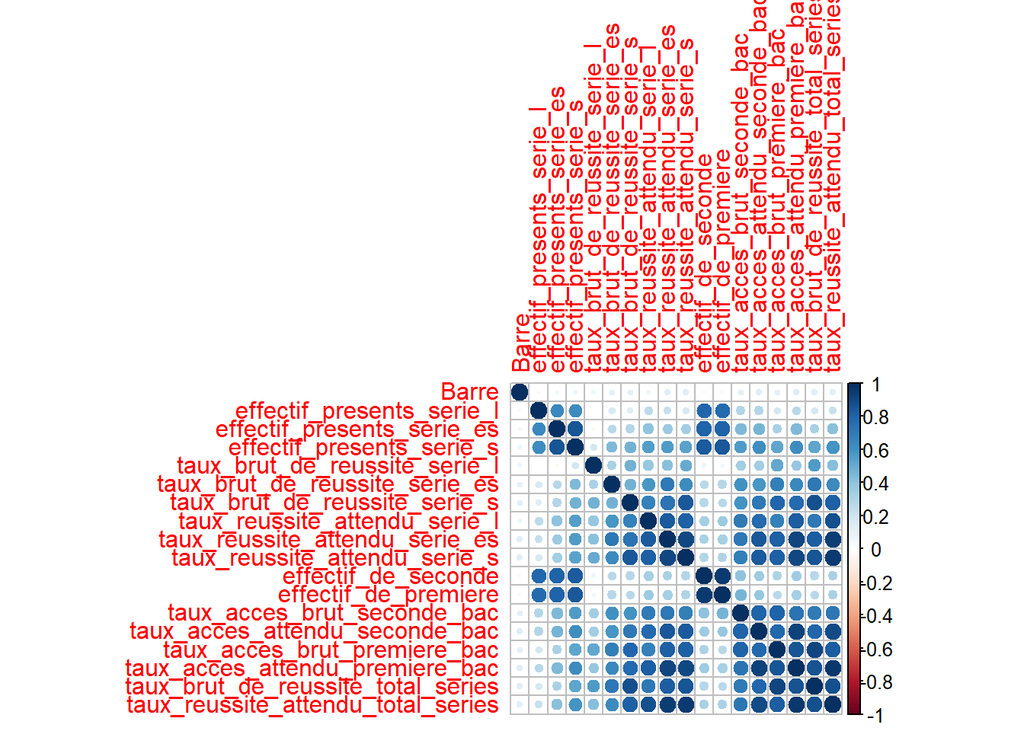

```r
# Corrélation des variables
corrplot(cor(D))
```

```r
cor(D$taux_reussite_attendu_serie_l, D$taux_acces_attendu_premiere_bac)
```

```
## [1] 0.8210166
```

```r
cor(D$taux_acces_attendu_seconde_bac, D$taux_brut_de_reussite_total_series)
```

```
## [1] 0.7966725
```

```r
cor(D$Barre, D$effectif_presents_serie_l)
```

```
## [1] 0.03822803
```

```r
cor(D$effectif_presents_serie_l, D$taux_acces_attendu_premiere_bac)
```

```
## [1] 0.2765599
```

```r
cor(D$taux_acces_brut_premiere_bac, D$effectif_presents_serie_es)
```

```
## [1] 0.3285668
```

Corrélation des variables: on voit certaines variables sont fortement corrélées et d’autres moins corrélées. On observe dans sur le graphe ci-dessus généralement des corrélations presque positives.

## Régression fréquentiste

```r
# régression fréquentiste

y = d_noduplicate$Barre
X = as.matrix(d_noduplicate[,-c(1:6)])
X = cbind(1,X)
dc = d_noduplicate[,-c(2:4)]
glimpse(X)
```

```
##  num [1:510, 1:18] 1 1 1 1 1 1 1 1 1 1 ...
##  - attr(*, "dimnames")=List of 2
##   ..$ : NULL
##   ..$ : chr [1:18] "" "effectif_presents_serie_l" "effectif_presents_serie_es" "effectif_presents_serie_s" ...
```

```r
lm(y~X)
```

```
##
## Call:
## lm(formula = y ~ X)
##
## Coefficients:
##                         (Intercept)                                    X
##                           -354.4063                                   NA
##          Xeffectif_presents_serie_l          Xeffectif_presents_serie_es
##                              0.7873                               0.3610
##          Xeffectif_presents_serie_s       Xtaux_brut_de_reussite_serie_l
##                              0.0743                               3.0739
##     Xtaux_brut_de_reussite_serie_es       Xtaux_brut_de_reussite_serie_s
##                              4.8218                               8.7738
##      Xtaux_reussite_attendu_serie_l      Xtaux_reussite_attendu_serie_es
##                            -13.2435                               4.2911
##      Xtaux_reussite_attendu_serie_s                 Xeffectif_de_seconde
##                             -2.8214                               0.1407
##               Xeffectif_de_premiere         Xtaux_acces_brut_seconde_bac
##                             -0.4567                               9.5490
##     Xtaux_acces_attendu_seconde_bac        Xtaux_acces_brut_premiere_bac
##                             -5.3452                             -19.8594
##    Xtaux_acces_attendu_premiere_bac  Xtaux_brut_de_reussite_total_series
##                             31.6030                              -5.3441
## Xtaux_reussite_attendu_total_series
##                             -6.2134
```

```r
summary(lm(Barre~Matiere, data = dc ))
```

```
##
## Call:
## lm(formula = Barre ~ Matiere, data = dc)
##
## Residuals:
##     Min      1Q  Median      3Q     Max
## -928.81 -160.19  -64.99   42.33 1535.07
##
## Coefficients:
##                   Estimate Std. Error t value Pr(>|t|)
## (Intercept)        535.271    103.552   5.169 3.47e-07 ***
## MatiereANGLAIS    -308.791    116.662  -2.647  0.00839 **
## MatiereARTS PLAST -372.771    292.890  -1.273  0.20374
## MatiereBIOCH.BIOL -393.738    189.060  -2.083  0.03782 *
## MatiereBIOTECHNOL -481.771    219.668  -2.193  0.02878 *
## MatiereDOC LYCEES -417.991    143.984  -2.903  0.00387 **
## MatiereE. P. S    -246.576    133.686  -1.844  0.06574 .
## MatiereECO.GE.COM -162.671    152.425  -1.067  0.28641
## MatiereECO.GE.CPT  412.979    219.668   1.880  0.06072 .
## MatiereECO.GE.FIN  442.540    138.070   3.205  0.00144 **
## MatiereECO.GE.MK  -242.431    143.984  -1.684  0.09289 .
## MatiereECO.GE.VEN -366.871    189.060  -1.941  0.05291 .
## MatiereEDUCATION  -355.366    136.471  -2.604  0.00950 **
## MatiereESPAGNOL   -362.571    125.408  -2.891  0.00401 **
## MatiereESTH.COSME -477.271    401.057  -1.190  0.23463
## MatiereG.ELECTRON -275.071    401.057  -0.686  0.49313
## MatiereG.ELECTROT -399.771    292.890  -1.365  0.17293
## MatiereG.IND.BOIS -493.271    401.057  -1.230  0.21933
## MatiereHIST. GEO. -263.140    117.971  -2.231  0.02618 *
## MatiereITALIEN     432.329    292.890   1.476  0.14059
## MatiereLET ANGLAI -146.146    171.722  -0.851  0.39516
## MatiereLET ESPAGN -385.521    219.668  -1.755  0.07990 .
## MatiereLET MODERN  -83.885    125.408  -0.669  0.50389
## MatiereLET.HIS.GE -331.641    149.235  -2.222  0.02674 *
## MatiereLETT CLASS -286.088    152.425  -1.877  0.06114 .
## MatiereMATH.SC.PH -277.005    165.540  -1.673  0.09492 .
## MatiereMATHS      -347.370    115.185  -3.016  0.00270 **
## MatiereNRC        -375.771    292.890  -1.283  0.20013
## MatierePHILO        -4.241    135.016  -0.031  0.97495
## MatierePHY.CHIMIE -204.214    133.686  -1.528  0.12728
## MatiereS. V. T.   -182.987    128.441  -1.425  0.15491
## MatiereSC.ECO.SOC -154.118    139.835  -1.102  0.27096
## MatiereSII.EE       62.062    189.060   0.328  0.74286
## MatiereSII.ING.ME  101.854    171.722   0.593  0.55338
## MatiereSII.SIN    -369.205    246.504  -1.498  0.13486
## ---
## Signif. codes:  0 '***' 0.001 '**' 0.01 '*' 0.05 '.' 0.1 ' ' 1
##
## Residual standard error: 387.5 on 475 degrees of freedom
## Multiple R-squared:  0.2046, Adjusted R-squared:  0.1477
## F-statistic: 3.595 on 34 and 475 DF,  p-value: 2.634e-10
```

Le modèle avec la variable Matiere converge sur les variables numériques, en effet les matières sont présentes une fois par établissement et dans plusieurs établissements et donc cela résout les problèmes de corrélation. La variabilité de Barre est trop importante entre les matières.Cela se vérifie dans les scores Adjusted R-squared (0.1477) pour le modèle avec Matiere seulement et p-value: 2.634e-10.

Le modèle avec seulement la variable Matiere fait ressortir que plusieurs matières ont un impact significatif sur la variable réponse. L’intercepté est également très significative.

```r
summary(lm(Barre~. -Matiere -code_etablissement, data = dc ))
```

```
##
## Call:
## lm(formula = Barre ~ . - Matiere - code_etablissement, data = dc)
##
## Residuals:
##     Min      1Q  Median      3Q     Max
## -439.13 -203.85 -124.73   -5.88 1652.64
##
## Coefficients:
##                                     Estimate Std. Error t value Pr(>|t|)
## (Intercept)                        -354.4063   556.9554  -0.636   0.5249
## effectif_presents_serie_l             0.7873     1.6276   0.484   0.6288
## effectif_presents_serie_es            0.3610     1.2323   0.293   0.7697
## effectif_presents_serie_s             0.0743     1.0130   0.073   0.9416
## taux_brut_de_reussite_serie_l         3.0739     2.5409   1.210   0.2270
## taux_brut_de_reussite_serie_es        4.8218     4.1911   1.150   0.2505
## taux_brut_de_reussite_serie_s         8.7738     6.3376   1.384   0.1669
## taux_reussite_attendu_serie_l       -13.2435     6.8578  -1.931   0.0540 .
## taux_reussite_attendu_serie_es        4.2911     8.2110   0.523   0.6015
## taux_reussite_attendu_serie_s        -2.8214     9.5235  -0.296   0.7672
## effectif_de_seconde                   0.1407     0.6186   0.227   0.8201
## effectif_de_premiere                 -0.4567     0.7136  -0.640   0.5225
## taux_acces_brut_seconde_bac           9.5490     5.6200   1.699   0.0899 .
## taux_acces_attendu_seconde_bac       -5.3452     8.9876  -0.595   0.5523
## taux_acces_brut_premiere_bac        -19.8594    10.6361  -1.867   0.0625 .
## taux_acces_attendu_premiere_bac      31.6030    19.0475   1.659   0.0977 .
## taux_brut_de_reussite_total_series   -5.3441    12.7932  -0.418   0.6763
## taux_reussite_attendu_total_series   -6.2134    21.9445  -0.283   0.7772
## ---
## Signif. codes:  0 '***' 0.001 '**' 0.01 '*' 0.05 '.' 0.1 ' ' 1
##
## Residual standard error: 418.8 on 492 degrees of freedom
## Multiple R-squared:  0.03765,    Adjusted R-squared:  0.004397
## F-statistic: 1.132 on 17 and 492 DF,  p-value: 0.319
```

le modèle avec variable numérique seulement est bien plus mauvais ,cela se vérifie dans les scores Adjusted R-squared (0.004397) et p-value: 0.319.

```r
summary(lm(Barre~code_etablissement+Matiere, data = dc ))
```

```
##
## Call:
## lm(formula = Barre ~ code_etablissement + Matiere, data = dc)
##
## Residuals:
##     Min      1Q  Median      3Q     Max
## -903.70 -156.24  -10.18   91.46 1328.85
##
## Coefficients:
##                            Estimate Std. Error t value Pr(>|t|)
## (Intercept)                 433.131    245.222   1.766  0.07817 .
## code_etablissement0780515L   25.170    330.200   0.076  0.93928
## code_etablissement0780582J -244.362    311.513  -0.784  0.43329
## code_etablissement0781297L   45.355    298.894   0.152  0.87947
## code_etablissement0781512V  375.205    291.738   1.286  0.19921
## code_etablissement0781819D  671.263    288.974   2.323  0.02073 *
## code_etablissement0781839A   54.833    290.093   0.189  0.85018
## code_etablissement0781845G   52.249    306.704   0.170  0.86482
## code_etablissement0781859X  116.906    252.311   0.463  0.64339
## code_etablissement0781860Y   37.681    323.520   0.116  0.90734
## code_etablissement0781861Z  -20.684    309.240  -0.067  0.94671
## code_etablissement0781883Y  343.474    276.335   1.243  0.21467
## code_etablissement0781884Z  882.854    347.978   2.537  0.01159 *
## code_etablissement0781949V   56.261    348.725   0.161  0.87192
## code_etablissement0781950W -119.895    272.835  -0.439  0.66060
## code_etablissement0781951X   52.941    257.130   0.206  0.83699
## code_etablissement0781952Y   60.968    440.169   0.139  0.88991
## code_etablissement0782132U   82.879    289.594   0.286  0.77489
## code_etablissement0782539L -133.805    296.145  -0.452  0.65166
## code_etablissement0782546U   38.778    349.803   0.111  0.91179
## code_etablissement0782549X  211.276    265.106   0.797  0.42599
## code_etablissement0782568T   96.792    309.411   0.313  0.75459
## code_etablissement0782587N  122.039    318.902   0.383  0.70217
## code_etablissement0782822U   18.269    258.572   0.071  0.94371
## code_etablissement0782924E -193.430    261.997  -0.738  0.46081
## code_etablissement0783140P   50.219    288.945   0.174  0.86212
## code_etablissement0910620E   -9.729    256.368  -0.038  0.96975
## code_etablissement0910621F  -15.657    272.615  -0.057  0.95423
## code_etablissement0910622G  -65.889    252.692  -0.261  0.79443
## code_etablissement0910623H -109.261    281.053  -0.389  0.69768
```

[output cut: 102 more lines]

```
## MatiereMATHS               -369.925    119.905  -3.085  0.00219 **
## MatiereNRC                 -432.695    334.621  -1.293  0.19679
## MatierePHILO                  4.450    142.297   0.031  0.97507
## MatierePHY.CHIMIE          -245.470    140.678  -1.745  0.08183 .
## MatiereS. V. T.            -222.099    135.009  -1.645  0.10081
## MatiereSC.ECO.SOC          -220.121    149.068  -1.477  0.14062
## MatiereSII.EE                88.005    195.573   0.450  0.65298
## MatiereSII.ING.ME           131.743    176.797   0.745  0.45665
## MatiereSII.SIN             -240.390    283.935  -0.847  0.39775
## ---
## Signif. codes:  0 '***' 0.001 '**' 0.01 '*' 0.05 '.' 0.1 ' ' 1
##
## Residual standard error: 371.9 on 369 degrees of freedom
## Multiple R-squared:  0.4306, Adjusted R-squared:  0.2146
## F-statistic: 1.993 on 140 and 369 DF,  p-value: 1.294e-07
```

Lorsque la régression est effectuée sur code_etablissement et Matiere les p-valeur significatifs des établissements sont globalement moins nombreux et moins élevés.

```r
reg.f= lm(Barre ~ ., data=D)
summary(reg.f)
```

```
##
## Call:
## lm(formula = Barre ~ ., data = D)
##
## Residuals:
##     Min      1Q  Median      3Q     Max
## -429.72 -205.90 -122.25   -8.55 1645.96
##
## Coefficients:
##                                      Estimate Std. Error t value Pr(>|t|)
## (Intercept)                        -4.725e+02  5.586e+02  -0.846   0.3980
## effectif_presents_serie_l           7.781e-01  1.638e+00   0.475   0.6351
## effectif_presents_serie_es          2.924e-01  1.234e+00   0.237   0.8128
## effectif_presents_serie_s           9.694e-03  1.019e+00   0.010   0.9924
## taux_brut_de_reussite_serie_l       3.122e+00  2.559e+00   1.220   0.2232
## taux_brut_de_reussite_serie_es      4.811e+00  4.205e+00   1.144   0.2531
## taux_brut_de_reussite_serie_s       9.385e+00  6.383e+00   1.470   0.1421
## taux_reussite_attendu_serie_l      -1.428e+01  6.879e+00  -2.077   0.0383 *
## taux_reussite_attendu_serie_es      3.814e+00  8.261e+00   0.462   0.6445
## taux_reussite_attendu_serie_s      -4.299e+00  9.586e+00  -0.448   0.6540
## effectif_de_seconde                 4.306e-02  6.229e-01   0.069   0.9449
## effectif_de_premiere               -3.521e-01  7.182e-01  -0.490   0.6242
## taux_acces_brut_seconde_bac         1.074e+01  5.655e+00   1.900   0.0580 .
## taux_acces_attendu_seconde_bac     -7.077e+00  9.038e+00  -0.783   0.4340
## taux_acces_brut_premiere_bac       -2.039e+01  1.071e+01  -1.904   0.0575 .
## taux_acces_attendu_premiere_bac     3.444e+01  1.916e+01   1.797   0.0729 .
## taux_brut_de_reussite_total_series -5.392e+00  1.288e+01  -0.419   0.6757
## taux_reussite_attendu_total_series -4.072e+00  2.202e+01  -0.185   0.8534
## ---
## Signif. codes:  0 '***' 0.001 '**' 0.01 '*' 0.05 '.' 0.1 ' ' 1
##
## Residual standard error: 422.4 on 498 degrees of freedom
## Multiple R-squared:  0.04068,    Adjusted R-squared:  0.007931
## F-statistic: 1.242 on 17 and 498 DF,  p-value: 0.2267
```

```r
reg.f.aic = step(reg.f)
```

```
## Start:  AIC=6257.03
## Barre ~ effectif_presents_serie_l + effectif_presents_serie_es +
##     effectif_presents_serie_s + taux_brut_de_reussite_serie_l +
##     taux_brut_de_reussite_serie_es + taux_brut_de_reussite_serie_s +
##     taux_reussite_attendu_serie_l + taux_reussite_attendu_serie_es +
##     taux_reussite_attendu_serie_s + effectif_de_seconde + effectif_de_premiere +
##     taux_acces_brut_seconde_bac + taux_acces_attendu_seconde_bac +
##     taux_acces_brut_premiere_bac + taux_acces_attendu_premiere_bac +
##     taux_brut_de_reussite_total_series + taux_reussite_attendu_total_series
##
##                                      Df Sum of Sq      RSS    AIC
## - effectif_presents_serie_s           1        16 88840876 6255.0
## - effectif_de_seconde                 1       852 88841713 6255.0
## - taux_reussite_attendu_total_series  1      6098 88846958 6255.1
## - effectif_presents_serie_es          1     10012 88850872 6255.1
## - taux_brut_de_reussite_total_series  1     31248 88872109 6255.2
## - taux_reussite_attendu_serie_s       1     35882 88876742 6255.2
## - taux_reussite_attendu_serie_es      1     38030 88878890 6255.2
## - effectif_presents_serie_l           1     40236 88881096 6255.3
## - effectif_de_premiere                1     42865 88883725 6255.3
## - taux_acces_attendu_seconde_bac      1    109391 88950251 6255.7
## - taux_brut_de_reussite_serie_es      1    233522 89074382 6256.4
## - taux_brut_de_reussite_serie_l       1    265394 89106254 6256.6
## <none>                                            88840860 6257.0
## - taux_brut_de_reussite_serie_s       1    385706 89226567 6257.3
## - taux_acces_attendu_premiere_bac     1    576250 89417110 6258.4
## - taux_acces_brut_seconde_bac         1    644017 89484878 6258.8
## - taux_acces_brut_premiere_bac        1    646888 89487748 6258.8
## - taux_reussite_attendu_serie_l       1    769345 89610205 6259.5
##
## Step:  AIC=6255.03
## Barre ~ effectif_presents_serie_l + effectif_presents_serie_es +
##     taux_brut_de_reussite_serie_l + taux_brut_de_reussite_serie_es +
##     taux_brut_de_reussite_serie_s + taux_reussite_attendu_serie_l +
##     taux_reussite_attendu_serie_es + taux_reussite_attendu_serie_s +
##     effectif_de_seconde + effectif_de_premiere + taux_acces_brut_seconde_bac +
##     taux_acces_attendu_seconde_bac + taux_acces_brut_premiere_bac +
##     taux_acces_attendu_premiere_bac + taux_brut_de_reussite_total_series +
##     taux_reussite_attendu_total_series
##
```

[output cut: 251 more lines]

```
##     taux_acces_attendu_premiere_bac
##
##                                   Df Sum of Sq      RSS    AIC
## - taux_acces_brut_seconde_bac      1    154234 90257096 6235.2
## <none>                                         90102863 6236.3
## - taux_reussite_attendu_serie_l    1    693957 90796819 6238.3
## - taux_acces_attendu_premiere_bac  1   1254445 91357307 6241.4
##
## Step:  AIC=6235.19
## Barre ~ taux_reussite_attendu_serie_l + taux_acces_attendu_premiere_bac
##
##                                   Df Sum of Sq      RSS    AIC
## <none>                                         90257096 6235.2
## - taux_reussite_attendu_serie_l    1    574942 90832038 6236.5
## - taux_acces_attendu_premiere_bac  1   1913707 92170804 6244.0
```

```r
summary(reg.f.aic)
```

```
##
## Call:
## lm(formula = Barre ~ taux_reussite_attendu_serie_l + taux_acces_attendu_premiere_bac,
##     data = D)
##
## Residuals:
##     Min      1Q  Median      3Q     Max
## -387.32 -196.56 -130.83  -14.95 1696.20
##
## Coefficients:
##                                 Estimate Std. Error t value Pr(>|t|)
## (Intercept)                     -494.324    260.593  -1.897  0.05840 .
## taux_reussite_attendu_serie_l     -7.882      4.360  -1.808  0.07124 .
## taux_acces_attendu_premiere_bac   17.833      5.407   3.298  0.00104 **
## ---
## Signif. codes:  0 '***' 0.001 '**' 0.01 '*' 0.05 '.' 0.1 ' ' 1
##
## Residual standard error: 419.5 on 513 degrees of freedom
## Multiple R-squared:  0.02539,    Adjusted R-squared:  0.02159
## F-statistic: 6.681 on 2 and 513 DF,  p-value: 0.001366
```

En effectuant une sélection de variables par la fonction step et le critère de l’AIC:

Lorsque l’ont inclus toutes les variables non catégorielles, le step sélection 2 variables: taux_acces_attendu_premiere_bac, taux_reussite_attendu_serie_l .

Lorsque l’on regarde les coefficients, on constate que:

L’intercepte est négative on pars donc d’une Barre négative, cependant le coefficient de taux_acces_attendu_premiere_bac est tellement importante que toutes les prédictions restent positives et celui avec la p-value (0.00104) la plus faible .

## Conclusion

Avant d’effectuer la régression linéaire bayésienne, nous avons effectué une régression linéaire standard pour expliquer la variable Barre :

La régression est faite sur toutes les variables numériques. Les variables Matiere et code_etablissement sont testés dans la régression, les autres variables sont redondantes ou n’apporte pas d’informations à ce stade.

Cette première approche nous permet de voir que:

Les modèles incluant code_etablissement ne convergent pas pour les variables numériques. Ce qui est normal, car toutes les variables numériques renseignent de paramètres d’effectif et de réussite propre à chaque établissement et donc complètement corrélés (toutes égales pour chaque établissement).

Cependant certaines classes de code_etablissement (certains établissements) ont des p-valeur significatifs:

Le modèle avec la variable Matiere converge sur les variables numériques, en effet les matières sont présentes une fois par établissement et dans plusieurs établissements et donc cela résout les problèmes de corrélation.

Le modèle avec seulement la variable Matiere fait ressortir que plusieurs matières ont un impact significatif sur la variable réponse. L’intercepté est également très significative.

Pour la suite on commencera donc à l’intéresser à la distribution de l’estimateur de la variable Barre grâce à la statistique Bayésienne. Dans un premier temps de façon générale, seulement grâce aux variables numériques afin d’obtenir plus d’information sur la dispersion de la variable lorsque l’ont le considère pas de matières ou établissement en particulier. Ensuite sur certaines matières en particulier afin de mieux comprendre les subtilités et l’influence des covaraibles numérique.

En effectuant une sélection de variables par la fonction step et le critère de l’AIC Lorsque l’ont inclus toutes les variables non catégorielles, le step sélection 2 variables: taux_acces_attendu_premiere_bac, taux_reussite_attendu_serie_l .

Lorsque l’on regarde les coefficients, on constate que:

L’intercepte est négative on pars donc d’une Barre négative, cependant le coefficient de taux_acces_attendu_premiere_bac est tellement importante que toutes les prédictions restent positives et celui avec la p-value (0.00104) la plus faible .

## Régression linéaire Bayésienne.

```r
# regression linéaire Bayésienne.

reg = MCMCregress(Barre ~ ., data=D)
summary(reg)
```

```
##
## Iterations = 1001:11000
## Thinning interval = 1
## Number of chains = 1
## Sample size per chain = 10000
##
## 1. Empirical mean and standard deviation for each variable,
##    plus standard error of the mean:
##
##                                          Mean        SD  Naive SE
## (Intercept)                        -4.712e+02 5.623e+02 5.623e+00
## effectif_presents_serie_l           7.479e-01 1.639e+00 1.639e-02
## effectif_presents_serie_es          2.930e-01 1.222e+00 1.222e-02
## effectif_presents_serie_s           2.685e-03 1.020e+00 1.020e-02
## taux_brut_de_reussite_serie_l       3.067e+00 2.546e+00 2.546e-02
## taux_brut_de_reussite_serie_es      4.719e+00 4.208e+00 4.208e-02
## taux_brut_de_reussite_serie_s       9.281e+00 6.322e+00 6.322e-02
## taux_reussite_attendu_serie_l      -1.423e+01 6.952e+00 6.952e-02
## taux_reussite_attendu_serie_es      3.928e+00 8.264e+00 8.264e-02
## taux_reussite_attendu_serie_s      -4.201e+00 9.597e+00 9.597e-02
## effectif_de_seconde                 5.518e-02 6.239e-01 6.239e-03
## effectif_de_premiere               -3.564e-01 7.169e-01 7.169e-03
## taux_acces_brut_seconde_bac         1.071e+01 5.695e+00 5.695e-02
## taux_acces_attendu_seconde_bac     -6.940e+00 9.029e+00 9.029e-02
## taux_acces_brut_premiere_bac       -2.040e+01 1.065e+01 1.065e-01
## taux_acces_attendu_premiere_bac     3.460e+01 1.916e+01 1.916e-01
## taux_brut_de_reussite_total_series -5.160e+00 1.289e+01 1.289e-01
## taux_reussite_attendu_total_series -4.571e+00 2.217e+01 2.217e-01
## sigma2                              1.792e+05 1.147e+04 1.147e+02
##                                    Time-series SE
## (Intercept)                             5.571e+00
## effectif_presents_serie_l               1.639e-02
## effectif_presents_serie_es              1.222e-02
## effectif_presents_serie_s               1.020e-02
## taux_brut_de_reussite_serie_l           2.546e-02
## taux_brut_de_reussite_serie_es          4.208e-02
## taux_brut_de_reussite_serie_s           6.070e-02
## taux_reussite_attendu_serie_l           6.952e-02
## taux_reussite_attendu_serie_es          8.264e-02
## taux_reussite_attendu_serie_s           9.597e-02
```

[output cut: 37 more lines]

```
## taux_brut_de_reussite_serie_l       8.089e+00
## taux_brut_de_reussite_serie_es      1.300e+01
## taux_brut_de_reussite_serie_s       2.175e+01
## taux_reussite_attendu_serie_l      -7.551e-01
## taux_reussite_attendu_serie_es      2.033e+01
## taux_reussite_attendu_serie_s       1.464e+01
## effectif_de_seconde                 1.266e+00
## effectif_de_premiere                1.026e+00
## taux_acces_brut_seconde_bac         2.172e+01
## taux_acces_attendu_seconde_bac      1.075e+01
## taux_acces_brut_premiere_bac        2.314e-01
## taux_acces_attendu_premiere_bac     7.209e+01
## taux_brut_de_reussite_total_series  1.986e+01
## taux_reussite_attendu_total_series  3.839e+01
## sigma2                              2.032e+05
```

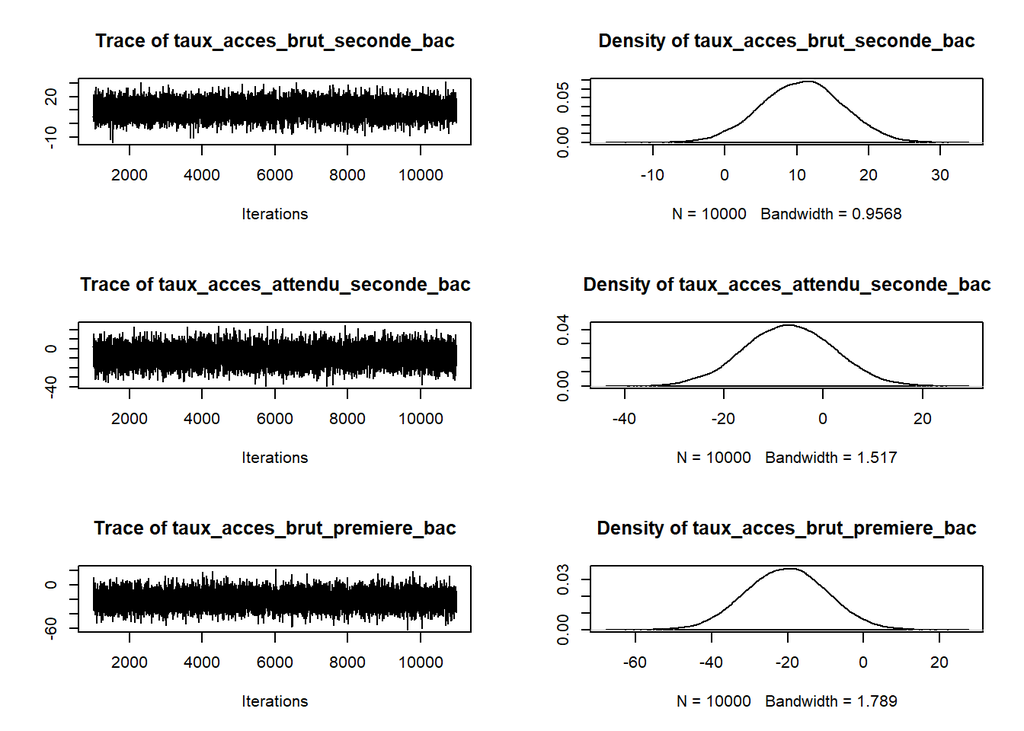

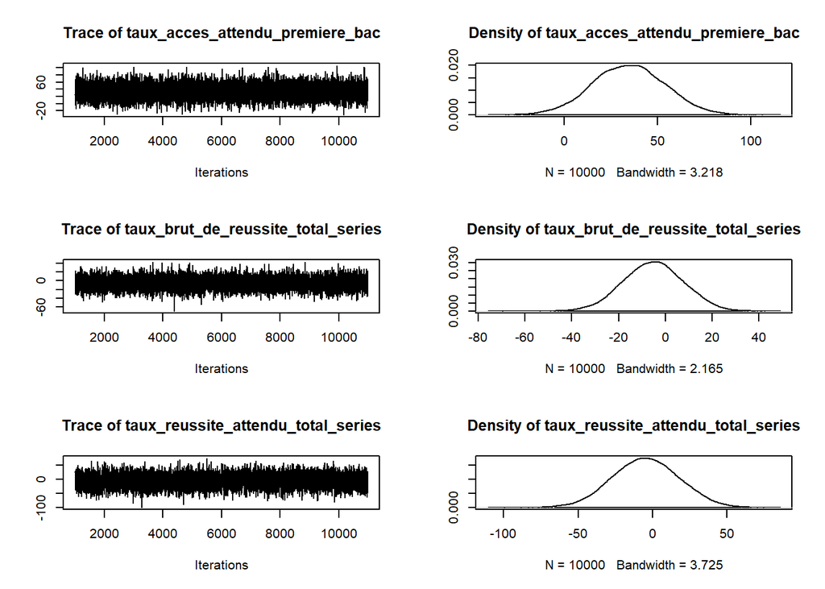

```r
plot(reg[, 13:18])
```

```r
raftery.diag(reg)
```

```
##
## Quantile (q) = 0.025
## Accuracy (r) = +/- 0.005
## Probability (s) = 0.95
##
##                                     Burn-in  Total Lower bound  Dependence
##                                     (M)      (N)   (Nmin)       factor (I)
##  (Intercept)                        2        3897  3746         1.040
##  effectif_presents_serie_l          2        3620  3746         0.966
##  effectif_presents_serie_es         2        3802  3746         1.010
##  effectif_presents_serie_s          2        3710  3746         0.990
##  taux_brut_de_reussite_serie_l      2        3834  3746         1.020
##  taux_brut_de_reussite_serie_es     2        3771  3746         1.010
##  taux_brut_de_reussite_serie_s      2        3834  3746         1.020
##  taux_reussite_attendu_serie_l      2        3680  3746         0.982
##  taux_reussite_attendu_serie_es     2        3620  3746         0.966
##  taux_reussite_attendu_serie_s      2        3771  3746         1.010
##  effectif_de_seconde                2        3710  3746         0.990
##  effectif_de_premiere               2        3834  3746         1.020
##  taux_acces_brut_seconde_bac        2        3710  3746         0.990
##  taux_acces_attendu_seconde_bac     2        3590  3746         0.958
##  taux_acces_brut_premiere_bac       2        3710  3746         0.990
##  taux_acces_attendu_premiere_bac    2        3834  3746         1.020
##  taux_brut_de_reussite_total_series 2        3834  3746         1.020
##  taux_reussite_attendu_total_series 2        3929  3746         1.050
##  sigma2                             2        3680  3746         0.982
```

```r
effectiveSize(reg)
```

```
##                        (Intercept)          effectif_presents_serie_l
##                          10185.315                          10000.000
##         effectif_presents_serie_es          effectif_presents_serie_s
##                          10000.000                          10000.000
##      taux_brut_de_reussite_serie_l     taux_brut_de_reussite_serie_es
##                          10000.000                          10000.000
##      taux_brut_de_reussite_serie_s      taux_reussite_attendu_serie_l
##                          10847.033                          10000.000
##     taux_reussite_attendu_serie_es      taux_reussite_attendu_serie_s
##                          10000.000                          10000.000
##                effectif_de_seconde               effectif_de_premiere
##                          10000.000                          10000.000
##        taux_acces_brut_seconde_bac     taux_acces_attendu_seconde_bac
##                          10000.000                          10082.533
##       taux_acces_brut_premiere_bac    taux_acces_attendu_premiere_bac
##                          10000.000                          10308.289
## taux_brut_de_reussite_total_series taux_reussite_attendu_total_series
##                          10453.020                          10000.000
##                             sigma2
##                           8936.514
```

raftery.diag:indique il nous faut au minimum 3746 itérations. On a fait 10000 itérations . Donc c’est bon en terme de nombre d’itérations.

Au niveau de taille effective de l’échantillon on est bon aussi.

```r
modBMS = bms(X.data=D, burn=1e4, iter=5e4)
```

```
##                                        PIP     Post Mean     Post SD
## taux_acces_attendu_premiere_bac    0.15532  1.597955e+00 4.112621724
## taux_acces_attendu_seconde_bac     0.11414  8.729544e-01 2.641555503
## taux_brut_de_reussite_total_series 0.05640  3.857002e-01 1.725629234
## taux_reussite_attendu_serie_s      0.05354  2.738694e-01 1.305773522
## taux_reussite_attendu_total_series 0.05006  2.785580e-01 1.742047800
## taux_reussite_attendu_serie_es     0.04960  2.915617e-01 1.428837613
## taux_acces_brut_premiere_bac       0.04568  2.983963e-01 1.539612944
## taux_acces_brut_seconde_bac        0.03896  1.964899e-01 1.083835962
## taux_brut_de_reussite_serie_s      0.03004  1.348164e-01 0.903645783
## taux_brut_de_reussite_serie_es     0.02744  1.155357e-01 0.780971150
## taux_reussite_attendu_serie_l      0.01540 -6.072890e-02 0.955612869
## effectif_presents_serie_s          0.01052  4.315213e-03 0.063699466
## effectif_de_premiere               0.01046  4.250730e-05 0.019376331
## taux_brut_de_reussite_serie_l      0.00980  1.715443e-02 0.259178531
## effectif_presents_serie_es         0.00648  1.597960e-03 0.056241282
## effectif_presents_serie_l          0.00502  1.478648e-03 0.071025676
## effectif_de_seconde                0.00350  5.547573e-06 0.009586621
##                                    Cond.Pos.Sign Idx
## taux_acces_attendu_premiere_bac        1.0000000  15
## taux_acces_attendu_seconde_bac         1.0000000  13
## taux_brut_de_reussite_total_series     1.0000000  16
## taux_reussite_attendu_serie_s          0.9779604   9
## taux_reussite_attendu_total_series     0.9540551  17
## taux_reussite_attendu_serie_es         0.9866936   8
## taux_acces_brut_premiere_bac           0.9851138  14
## taux_acces_brut_seconde_bac            1.0000000  12
## taux_brut_de_reussite_serie_s          1.0000000   6
## taux_brut_de_reussite_serie_es         1.0000000   5
## taux_reussite_attendu_serie_l          0.2974026   7
## effectif_presents_serie_s              0.9353612   3
## effectif_de_premiere                   0.4894837  11
## taux_brut_de_reussite_serie_l          1.0000000   4
## effectif_presents_serie_es             0.7500000   2
## effectif_presents_serie_l              0.6533864   1
## effectif_de_seconde                    0.5142857  10
##
## Mean no. regressors               Draws             Burnins                Time
##            "0.6824"             "50000"             "10000"     "6.727579 secs"
##  No. models visited      Modelspace 2^K           % visited         % Topmodels
##              "4789"            "131072"               "3.7"               "100"
##            Corr PMP            No. Obs.         Model Prior             g-Prior
##            "0.9990"               "516"      "random / 8.5"               "UIP"
##     Shrinkage-Stats
##         "Av=0.9981"
##
## Time difference of 6.727579 secs
```

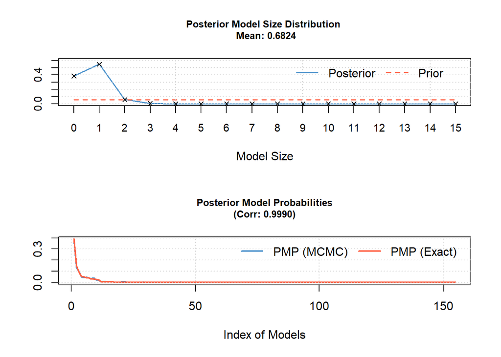

```r
coef(modBMS)
```

```
##                                        PIP     Post Mean     Post SD
## taux_acces_attendu_premiere_bac    0.15532  1.597955e+00 4.112621724
## taux_acces_attendu_seconde_bac     0.11414  8.729544e-01 2.641555503
## taux_brut_de_reussite_total_series 0.05640  3.857002e-01 1.725629234
## taux_reussite_attendu_serie_s      0.05354  2.738694e-01 1.305773522
## taux_reussite_attendu_total_series 0.05006  2.785580e-01 1.742047800
## taux_reussite_attendu_serie_es     0.04960  2.915617e-01 1.428837613
## taux_acces_brut_premiere_bac       0.04568  2.983963e-01 1.539612944
## taux_acces_brut_seconde_bac        0.03896  1.964899e-01 1.083835962
## taux_brut_de_reussite_serie_s      0.03004  1.348164e-01 0.903645783
## taux_brut_de_reussite_serie_es     0.02744  1.155357e-01 0.780971150
## taux_reussite_attendu_serie_l      0.01540 -6.072890e-02 0.955612869
## effectif_presents_serie_s          0.01052  4.315213e-03 0.063699466
## effectif_de_premiere               0.01046  4.250730e-05 0.019376331
## taux_brut_de_reussite_serie_l      0.00980  1.715443e-02 0.259178531
## effectif_presents_serie_es         0.00648  1.597960e-03 0.056241282
## effectif_presents_serie_l          0.00502  1.478648e-03 0.071025676
## effectif_de_seconde                0.00350  5.547573e-06 0.009586621
##                                    Cond.Pos.Sign Idx
## taux_acces_attendu_premiere_bac        1.0000000  15
## taux_acces_attendu_seconde_bac         1.0000000  13
## taux_brut_de_reussite_total_series     1.0000000  16
## taux_reussite_attendu_serie_s          0.9779604   9
## taux_reussite_attendu_total_series     0.9540551  17
## taux_reussite_attendu_serie_es         0.9866936   8
## taux_acces_brut_premiere_bac           0.9851138  14
## taux_acces_brut_seconde_bac            1.0000000  12
## taux_brut_de_reussite_serie_s          1.0000000   6
## taux_brut_de_reussite_serie_es         1.0000000   5
## taux_reussite_attendu_serie_l          0.2974026   7
## effectif_presents_serie_s              0.9353612   3
## effectif_de_premiere                   0.4894837  11
## taux_brut_de_reussite_serie_l          1.0000000   4
## effectif_presents_serie_es             0.7500000   2
## effectif_presents_serie_l              0.6533864   1
## effectif_de_seconde                    0.5142857  10
```

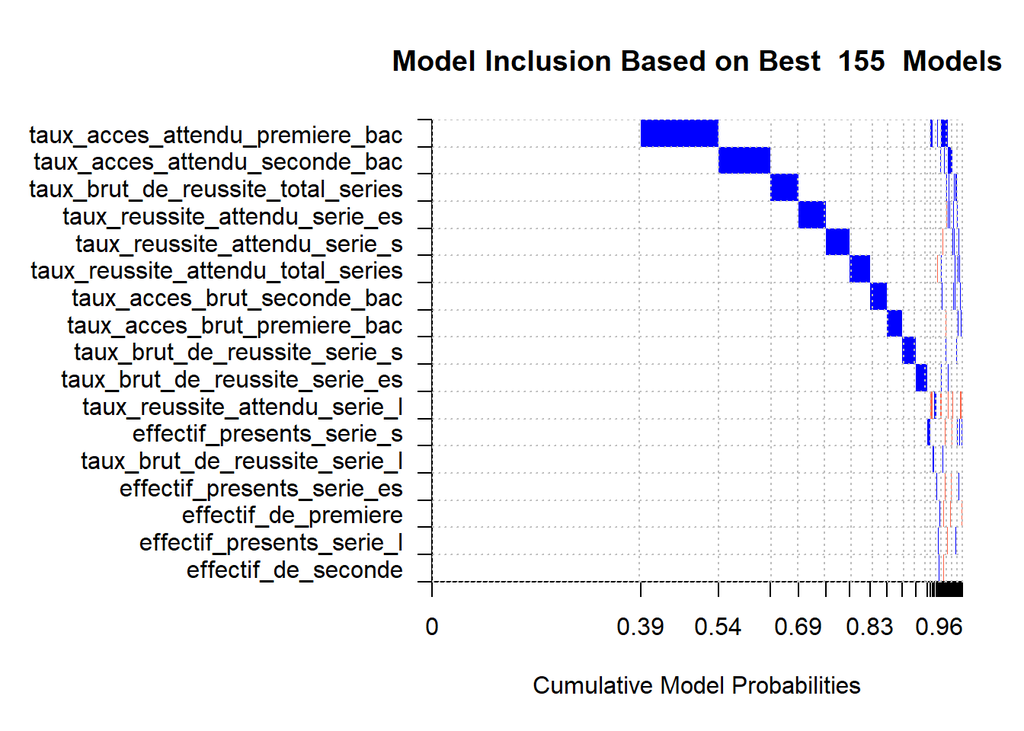

```r
image(modBMS)
```

```r
topmodels.bma(modBMS)[, 1:18]
```

```
##                                        00000     00004      00010      00002
## effectif_presents_serie_l          0.0000000 0.0000000 0.00000000 0.00000000
## effectif_presents_serie_es         0.0000000 0.0000000 0.00000000 0.00000000
## effectif_presents_serie_s          0.0000000 0.0000000 0.00000000 0.00000000
## taux_brut_de_reussite_serie_l      0.0000000 0.0000000 0.00000000 0.00000000
## taux_brut_de_reussite_serie_es     0.0000000 0.0000000 0.00000000 0.00000000
## taux_brut_de_reussite_serie_s      0.0000000 0.0000000 0.00000000 0.00000000
## taux_reussite_attendu_serie_l      0.0000000 0.0000000 0.00000000 0.00000000
## taux_reussite_attendu_serie_es     0.0000000 0.0000000 0.00000000 0.00000000
## taux_reussite_attendu_serie_s      0.0000000 0.0000000 0.00000000 0.00000000
## effectif_de_seconde                0.0000000 0.0000000 0.00000000 0.00000000
## effectif_de_premiere               0.0000000 0.0000000 0.00000000 0.00000000
## taux_acces_brut_seconde_bac        0.0000000 0.0000000 0.00000000 0.00000000
## taux_acces_attendu_seconde_bac     0.0000000 0.0000000 1.00000000 0.00000000
## taux_acces_brut_premiere_bac       0.0000000 0.0000000 0.00000000 0.00000000
## taux_acces_attendu_premiere_bac    0.0000000 1.0000000 0.00000000 0.00000000
## taux_brut_de_reussite_total_series 0.0000000 0.0000000 0.00000000 1.00000000
## taux_reussite_attendu_total_series 0.0000000 0.0000000 0.00000000 0.00000000
## PMP (Exact)                        0.3932367 0.1474866 0.09714587 0.05382901
## PMP (MCMC)                         0.3860800 0.1351000 0.09922000 0.04850000
##                                         00200      00100      00001      00020
## effectif_presents_serie_l          0.00000000 0.00000000 0.00000000 0.00000000
## effectif_presents_serie_es         0.00000000 0.00000000 0.00000000 0.00000000
## effectif_presents_serie_s          0.00000000 0.00000000 0.00000000 0.00000000
## taux_brut_de_reussite_serie_l      0.00000000 0.00000000 0.00000000 0.00000000
## taux_brut_de_reussite_serie_es     0.00000000 0.00000000 0.00000000 0.00000000
## taux_brut_de_reussite_serie_s      0.00000000 0.00000000 0.00000000 0.00000000
## taux_reussite_attendu_serie_l      0.00000000 0.00000000 0.00000000 0.00000000
## taux_reussite_attendu_serie_es     1.00000000 0.00000000 0.00000000 0.00000000
## taux_reussite_attendu_serie_s      0.00000000 1.00000000 0.00000000 0.00000000
## effectif_de_seconde                0.00000000 0.00000000 0.00000000 0.00000000
## effectif_de_premiere               0.00000000 0.00000000 0.00000000 0.00000000
## taux_acces_brut_seconde_bac        0.00000000 0.00000000 0.00000000 1.00000000
## taux_acces_attendu_seconde_bac     0.00000000 0.00000000 0.00000000 0.00000000
## taux_acces_brut_premiere_bac       0.00000000 0.00000000 0.00000000 0.00000000
## taux_acces_attendu_premiere_bac    0.00000000 0.00000000 0.00000000 0.00000000
## taux_brut_de_reussite_total_series 0.00000000 0.00000000 0.00000000 0.00000000
## taux_reussite_attendu_total_series 0.00000000 0.00000000 1.00000000 0.00000000
## PMP (Exact)                        0.05140937 0.04379483 0.03989065 0.03114078
## PMP (MCMC)                         0.04236000 0.04654000 0.03876000 0.03308000
```

[output cut: 45 more lines]

```
## taux_brut_de_reussite_serie_es     0.000000000 0.000000000 0.000000000
## taux_brut_de_reussite_serie_s      0.000000000 0.000000000 0.000000000
## taux_reussite_attendu_serie_l      0.000000000 0.000000000 0.000000000
## taux_reussite_attendu_serie_es     0.000000000 0.000000000 0.000000000
## taux_reussite_attendu_serie_s      0.000000000 0.000000000 0.000000000
## effectif_de_seconde                0.000000000 0.000000000 0.000000000
## effectif_de_premiere               0.000000000 0.000000000 0.000000000
## taux_acces_brut_seconde_bac        0.000000000 0.000000000 0.000000000
## taux_acces_attendu_seconde_bac     0.000000000 0.000000000 0.000000000
## taux_acces_brut_premiere_bac       0.000000000 0.000000000 0.000000000
## taux_acces_attendu_premiere_bac    0.000000000 1.000000000 0.000000000
## taux_brut_de_reussite_total_series 0.000000000 0.000000000 0.000000000
## taux_reussite_attendu_total_series 0.000000000 1.000000000 0.000000000
## PMP (Exact)                        0.002078862 0.001862573 0.001481462
## PMP (MCMC)                         0.001880000 0.002080000 0.001120000
```

# Comparaison avec le modèle fréquentiste

En effectuant une sélection de variables par la fonction step et le critère de l’AIC:

lorsque l’ont inclus toutes les variables non catégorielles, le step sélectionne 2 variables: taux_acces_attendu_premiere_bac, taux_reussite_attendu_serie_l .

En détail : Lorsque l’on regarde les coefficients, on constate que:

L’intercepte est négative on pars donc d’une Barre négative, cependant le coefficient de taux_acces_attendu_premiere_bac est tellement importante que toutes les prédictions restent positives.

Le coeficient de taux_reussite_attendu_serie_l est négatif. Ce qui laisse penser que la Barre d’accès diminue losque l’établissement à un meilleur taux de réussite pour la section L.

Finalement on constate que taux_acces_attendu_premiere_bac qui est la variable donc le coefficient et les plus vraisemblablement différents de 0 avec l’approche Bayésienne est également celui avec la p-value la plus faible (0.00104) pour la sélection de variables du modèle linéaire avec le step et l’AIC.

# Mutations en mathématiques et anglais

Ces matières sont parmi celles les plus représentés dans le jeu de données avec respectivement 52 et 59 individus (établissements) pour l’Anglais et la Mathématiques. Parmi ceux-ci, 31 Matiere sont issues du même établissement.

```r
#  les mutations en math et anglais.

d_AN =  d_noduplicate[,-c(1:4)] %>% filter(Matiere == "ANGLAIS")
d_AN = d_AN[,-1]
modMCMC_Ang = MCMCregress(Barre ~ ., data=d_AN)
summary(modMCMC_Ang)
```

```
##
## Iterations = 1001:11000
## Thinning interval = 1
## Number of chains = 1
## Sample size per chain = 10000
##
## 1. Empirical mean and standard deviation for each variable,
##    plus standard error of the mean:
##
##                                          Mean        SD  Naive SE
## (Intercept)                        -1299.0486  1917.238  19.17238
## effectif_presents_serie_l             -5.2984     5.842   0.05842
## effectif_presents_serie_es            -1.6444     2.798   0.02798
## effectif_presents_serie_s              0.7715     2.400   0.02400
## taux_brut_de_reussite_serie_l         -5.1882     5.945   0.05945
## taux_brut_de_reussite_serie_es         5.8831     9.167   0.09167
## taux_brut_de_reussite_serie_s          2.7664    15.284   0.15284
## taux_reussite_attendu_serie_l         -3.7352    20.099   0.20099
## taux_reussite_attendu_serie_es        31.1012    18.146   0.18146
## taux_reussite_attendu_serie_s        -24.5749    20.727   0.20727
## effectif_de_seconde                    1.2661     1.590   0.01590
## effectif_de_premiere                  -1.0286     2.053   0.02053
## taux_acces_brut_seconde_bac            8.9345    14.110   0.14110
## taux_acces_attendu_seconde_bac       -30.3911    23.568   0.23568
## taux_acces_brut_premiere_bac         -42.2324    25.807   0.25807
## taux_acces_attendu_premiere_bac      104.0114    53.530   0.53530
## taux_brut_de_reussite_total_series    33.1400    32.268   0.32268
## taux_reussite_attendu_total_series   -63.2913    55.820   0.55820
## sigma2                             88287.3373 22795.847 227.95847
##                                    Time-series SE
## (Intercept)                              19.17238
## effectif_presents_serie_l                 0.05842
## effectif_presents_serie_es                0.02798
## effectif_presents_serie_s                 0.02393
## taux_brut_de_reussite_serie_l             0.05512
## taux_brut_de_reussite_serie_es            0.09167
## taux_brut_de_reussite_serie_s             0.14781
## taux_reussite_attendu_serie_l             0.19468
## taux_reussite_attendu_serie_es            0.17898
## taux_reussite_attendu_serie_s             0.20365
```

[output cut: 37 more lines]

```
## taux_brut_de_reussite_serie_l      6.547e+00
## taux_brut_de_reussite_serie_es     2.387e+01
## taux_brut_de_reussite_serie_s      3.275e+01
## taux_reussite_attendu_serie_l      3.663e+01
## taux_reussite_attendu_serie_es     6.738e+01
## taux_reussite_attendu_serie_s      1.715e+01
## effectif_de_seconde                4.374e+00
## effectif_de_premiere               2.987e+00
## taux_acces_brut_seconde_bac        3.616e+01
## taux_acces_attendu_seconde_bac     1.568e+01
## taux_acces_brut_premiere_bac       8.657e+00
## taux_acces_attendu_premiere_bac    2.096e+02
## taux_brut_de_reussite_total_series 9.588e+01
## taux_reussite_attendu_total_series 4.860e+01
## sigma2                             1.424e+05
```

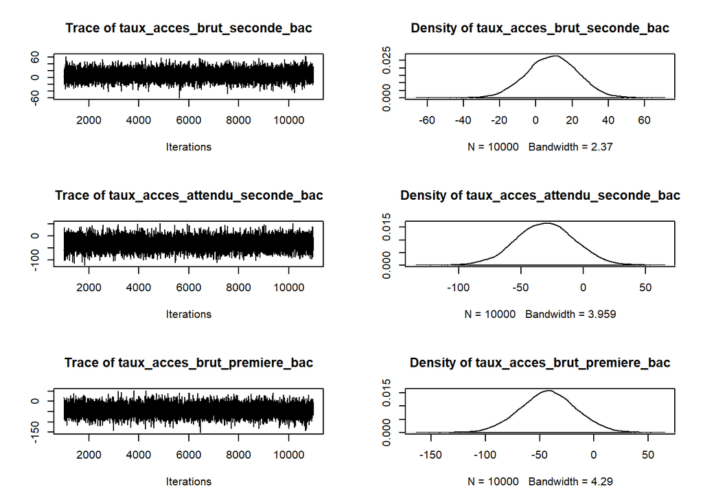

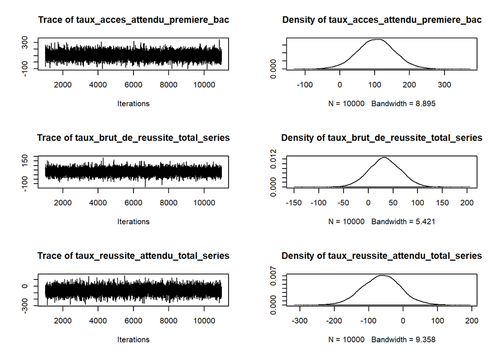

```r
par(mfrow=c(6,3))
plot(modMCMC_Ang[, 13:18])
```

```r
raftery.diag(modMCMC_Ang)
```

```
##
## Quantile (q) = 0.025
## Accuracy (r) = +/- 0.005
## Probability (s) = 0.95
##
##                                     Burn-in  Total Lower bound  Dependence
##                                     (M)      (N)   (Nmin)       factor (I)
##  (Intercept)                        2        3865  3746         1.030
##  effectif_presents_serie_l          2        3741  3746         0.999
##  effectif_presents_serie_es         2        3680  3746         0.982
##  effectif_presents_serie_s          2        3929  3746         1.050
##  taux_brut_de_reussite_serie_l      2        3710  3746         0.990
##  taux_brut_de_reussite_serie_es     3        4028  3746         1.080
##  taux_brut_de_reussite_serie_s      2        3962  3746         1.060
##  taux_reussite_attendu_serie_l      2        3929  3746         1.050
##  taux_reussite_attendu_serie_es     2        3802  3746         1.010
##  taux_reussite_attendu_serie_s      2        3802  3746         1.010
##  effectif_de_seconde                2        3962  3746         1.060
##  effectif_de_premiere               2        3834  3746         1.020
##  taux_acces_brut_seconde_bac        2        3834  3746         1.020
##  taux_acces_attendu_seconde_bac     2        3710  3746         0.990
##  taux_acces_brut_premiere_bac       2        3680  3746         0.982
##  taux_acces_attendu_premiere_bac    3        4095  3746         1.090
##  taux_brut_de_reussite_total_series 2        3865  3746         1.030
##  taux_reussite_attendu_total_series 2        3802  3746         1.010
##  sigma2                             3        4338  3746         1.160
```

```r
effectiveSize(modMCMC_Ang)
```

```
##                        (Intercept)          effectif_presents_serie_l
##                          10000.000                          10000.000
##         effectif_presents_serie_es          effectif_presents_serie_s
##                          10000.000                          10057.752
##      taux_brut_de_reussite_serie_l     taux_brut_de_reussite_serie_es
##                          11631.125                          10000.000
##      taux_brut_de_reussite_serie_s      taux_reussite_attendu_serie_l
##                          10691.940                          10658.956
##     taux_reussite_attendu_serie_es      taux_reussite_attendu_serie_s
##                          10279.013                          10358.749
##                effectif_de_seconde               effectif_de_premiere
##                          10000.000                          10000.000
##        taux_acces_brut_seconde_bac     taux_acces_attendu_seconde_bac
##                          10000.000                          10000.000
##       taux_acces_brut_premiere_bac    taux_acces_attendu_premiere_bac
##                           9664.536                           9617.597
## taux_brut_de_reussite_total_series taux_reussite_attendu_total_series
##                          11356.223                           9552.972
##                             sigma2
##                           4459.364
```

```r
d_MA =  d_noduplicate[,-c(1:4)] %>% filter(Matiere == "MATHS")
d_MA = d_MA[,-1]

modMCMC_MA = MCMCregress(Barre ~ ., data=d_MA)
summary(modMCMC_MA)
```

```
##
## Iterations = 1001:11000
## Thinning interval = 1
## Number of chains = 1
## Sample size per chain = 10000
##
## 1. Empirical mean and standard deviation for each variable,
##    plus standard error of the mean:
##
##                                          Mean        SD  Naive SE
## (Intercept)                           67.4523  500.0076  5.000076
## effectif_presents_serie_l              0.4013    1.2837  0.012837
## effectif_presents_serie_es            -0.3867    0.9701  0.009701
## effectif_presents_serie_s              1.1703    0.8663  0.008663
## taux_brut_de_reussite_serie_l         -3.6940    2.1484  0.021484
## taux_brut_de_reussite_serie_es         7.2346    4.2445  0.042445
## taux_brut_de_reussite_serie_s          1.4298    5.6936  0.056936
## taux_reussite_attendu_serie_l         -4.1673    5.8405  0.058405
## taux_reussite_attendu_serie_es        -6.1565    7.3670  0.073670
## taux_reussite_attendu_serie_s         -2.0245    8.5632  0.085632
## effectif_de_seconde                    0.8110    0.5426  0.005426
## effectif_de_premiere                  -1.4121    0.6550  0.006550
## taux_acces_brut_seconde_bac           13.2278    6.3089  0.063089
## taux_acces_attendu_seconde_bac        -9.2566    7.4632  0.074632
## taux_acces_brut_premiere_bac         -12.8203   10.6022  0.106022
## taux_acces_attendu_premiere_bac        5.8948   15.2374  0.152374
## taux_brut_de_reussite_total_series     1.5784   11.1902  0.111902
## taux_reussite_attendu_total_series    11.1336   18.1748  0.181748
## sigma2                             14280.1921 3322.8942 33.228942
##                                    Time-series SE
## (Intercept)                              5.043451
## effectif_presents_serie_l                0.012837
## effectif_presents_serie_es               0.009701
## effectif_presents_serie_s                0.008408
## taux_brut_de_reussite_serie_l            0.021048
## taux_brut_de_reussite_serie_es           0.042126
## taux_brut_de_reussite_serie_s            0.056936
## taux_reussite_attendu_serie_l            0.058405
## taux_reussite_attendu_serie_es           0.072475
## taux_reussite_attendu_serie_s            0.083186
```

[output cut: 37 more lines]

```
## taux_brut_de_reussite_serie_l          0.4996
## taux_brut_de_reussite_serie_es        15.5475
## taux_brut_de_reussite_serie_s         12.7086
## taux_reussite_attendu_serie_l          7.3722
## taux_reussite_attendu_serie_es         8.4961
## taux_reussite_attendu_serie_s         15.0643
## effectif_de_seconde                    1.8809
## effectif_de_premiere                  -0.1325
## taux_acces_brut_seconde_bac           25.6278
## taux_acces_attendu_seconde_bac         5.2425
## taux_acces_brut_premiere_bac           8.1238
## taux_acces_attendu_premiere_bac       35.8679
## taux_brut_de_reussite_total_series    23.1985
## taux_reussite_attendu_total_series    46.6924
## sigma2                             21923.2032
```

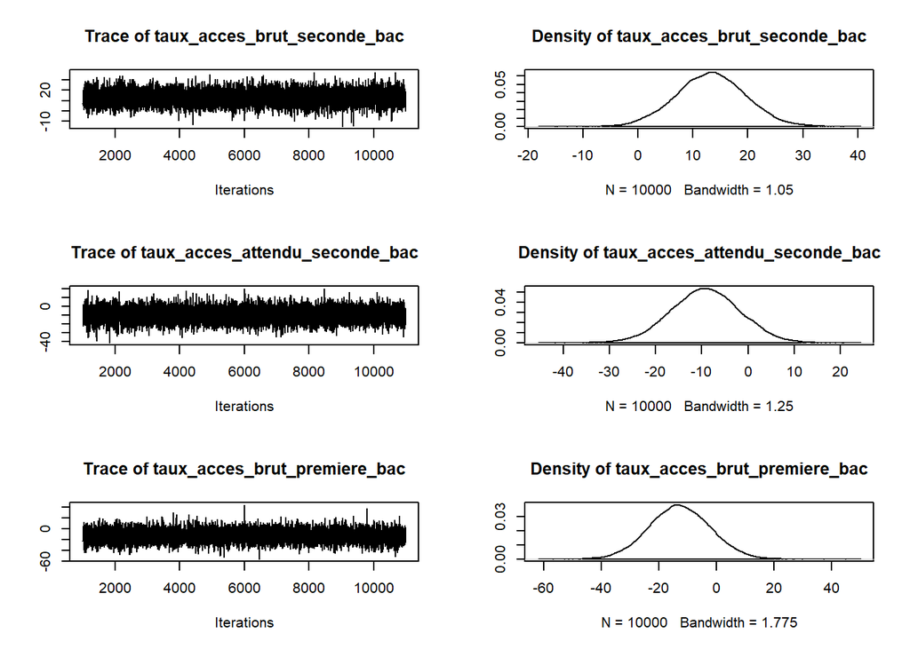

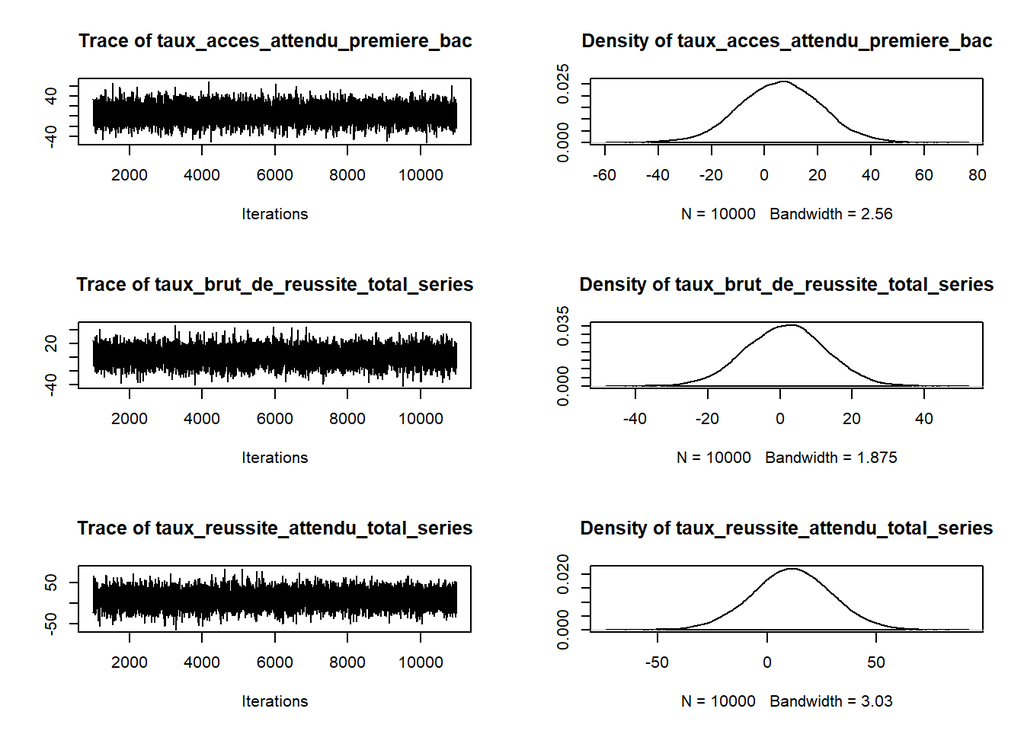

```r
plot(modMCMC_MA[, 13:18])
```

```r
raftery.diag(modMCMC_MA)
```

```
##
## Quantile (q) = 0.025
## Accuracy (r) = +/- 0.005
## Probability (s) = 0.95
##
##                                     Burn-in  Total Lower bound  Dependence
##                                     (M)      (N)   (Nmin)       factor (I)
##  (Intercept)                        2        3897  3746         1.040
##  effectif_presents_serie_l          2        3680  3746         0.982
##  effectif_presents_serie_es         2        3650  3746         0.974
##  effectif_presents_serie_s          2        3802  3746         1.010
##  taux_brut_de_reussite_serie_l      2        3650  3746         0.974
##  taux_brut_de_reussite_serie_es     2        3962  3746         1.060
##  taux_brut_de_reussite_serie_s      2        3802  3746         1.010
##  taux_reussite_attendu_serie_l      2        3741  3746         0.999
##  taux_reussite_attendu_serie_es     2        3710  3746         0.990
##  taux_reussite_attendu_serie_s      2        3897  3746         1.040
##  effectif_de_seconde                2        3865  3746         1.030
##  effectif_de_premiere               2        3897  3746         1.040
##  taux_acces_brut_seconde_bac        2        3741  3746         0.999
##  taux_acces_attendu_seconde_bac     2        3802  3746         1.010
##  taux_acces_brut_premiere_bac       2        3834  3746         1.020
##  taux_acces_attendu_premiere_bac    2        3994  3746         1.070
##  taux_brut_de_reussite_total_series 2        3834  3746         1.020
##  taux_reussite_attendu_total_series 2        3834  3746         1.020
##  sigma2                             3        4232  3746         1.130
```

```r
effectiveSize(modMCMC_MA)
```

```
##                        (Intercept)          effectif_presents_serie_l
##                           9828.732                          10000.000
##         effectif_presents_serie_es          effectif_presents_serie_s
##                          10000.000                          10614.569
##      taux_brut_de_reussite_serie_l     taux_brut_de_reussite_serie_es
##                          10418.570                          10151.902
##      taux_brut_de_reussite_serie_s      taux_reussite_attendu_serie_l
##                          10000.000                          10000.000
##     taux_reussite_attendu_serie_es      taux_reussite_attendu_serie_s
##                          10332.411                          10596.699
##                effectif_de_seconde               effectif_de_premiere
##                          10000.000                           9557.799
##        taux_acces_brut_seconde_bac     taux_acces_attendu_seconde_bac
##                          10000.000                          10000.000
##       taux_acces_brut_premiere_bac    taux_acces_attendu_premiere_bac
##                           9717.719                           9613.253
## taux_brut_de_reussite_total_series taux_reussite_attendu_total_series
##                          10000.000                          10000.000
##                             sigma2
##                           4719.425
```

## Conclusion

En comparant les coefficients trouvés, on constate que:

Certaines variables ont des coefficients relativement proches avec des valeurs proches et le même signe.

Certaines variables sont du même signe, mais avec des valeurs de coefficients assez éloignés.

Certaines variables ont des coefficients de signes opposés.

Ainsi on peut conclure que les covariables agissent de manière différente pour ces deux disciplines. Surtout pour les variables avec des coefficients de signes opposés.